# Risk Factor Analysis

## Outcome Variable

**Outcome Variable:** dead6plus

## Predictor Variables

**Intervention Variable:** ever_co06

**Adjustment Set:**

- sex
- arm
- brthmon
- vagbrth
- impfloor
- hhwealth_quart
- W_mage
- W_mhtcm
- W_mwtkg
- W_mbmi
- W_meducyrs
- W_feducyrs
- W_nrooms
- W_parity
- impsan
- safeh20
- delta_vagbrth
- delta_impfloor
- delta_hhwealth_quart
- delta_W_mage
- delta_W_mhtcm
- delta_W_mwtkg
- delta_W_mbmi
- delta_W_meducyrs
- delta_W_feducyrs
- delta_W_nrooms
- delta_W_parity
- delta_impsan
- delta_safeh20

## Stratifying Variables

The analysis was stratified on these variable(s):

- studyid
- country

## Data Summary

| studyid | country | ever_co06 | dead6plus | n_cell | n | outcome_variable |
| --- | --- | --- | --- | --- | --- | --- |
| Burkina Faso Zn | BURKINA FASO | 0 | 0 | 323 | 336 | dead6plus |
| Burkina Faso Zn | BURKINA FASO | 0 | 1 | 2 | 336 | dead6plus |
| Burkina Faso Zn | BURKINA FASO | 1 | 0 | 11 | 336 | dead6plus |
| Burkina Faso Zn | BURKINA FASO | 1 | 1 | 0 | 336 | dead6plus |
| EE | PAKISTAN | 0 | 0 | 310 | 374 | dead6plus |
| EE | PAKISTAN | 0 | 1 | 2 | 374 | dead6plus |
| EE | PAKISTAN | 1 | 0 | 60 | 374 | dead6plus |
| EE | PAKISTAN | 1 | 1 | 2 | 374 | dead6plus |
| GMS-Nepal | NEPAL | 0 | 0 | 557 | 592 | dead6plus |
| GMS-Nepal | NEPAL | 0 | 1 | 1 | 592 | dead6plus |
| GMS-Nepal | NEPAL | 1 | 0 | 33 | 592 | dead6plus |
| GMS-Nepal | NEPAL | 1 | 1 | 1 | 592 | dead6plus |
| iLiNS-DOSE | MALAWI | 0 | 0 | 1631 | 1756 | dead6plus |
| iLiNS-DOSE | MALAWI | 0 | 1 | 110 | 1756 | dead6plus |
| iLiNS-DOSE | MALAWI | 1 | 0 | 12 | 1756 | dead6plus |
| iLiNS-DOSE | MALAWI | 1 | 1 | 3 | 1756 | dead6plus |
| iLiNS-DYAD-M | MALAWI | 0 | 0 | 1102 | 1142 | dead6plus |
| iLiNS-DYAD-M | MALAWI | 0 | 1 | 25 | 1142 | dead6plus |
| iLiNS-DYAD-M | MALAWI | 1 | 0 | 12 | 1142 | dead6plus |
| iLiNS-DYAD-M | MALAWI | 1 | 1 | 3 | 1142 | dead6plus |
| JiVitA-3 | BANGLADESH | 0 | 0 | 19694 | 20966 | dead6plus |
| JiVitA-3 | BANGLADESH | 0 | 1 | 249 | 20966 | dead6plus |
| JiVitA-3 | BANGLADESH | 1 | 0 | 973 | 20966 | dead6plus |
| JiVitA-3 | BANGLADESH | 1 | 1 | 50 | 20966 | dead6plus |
| JiVitA-4 | BANGLADESH | 0 | 0 | 5008 | 5237 | dead6plus |
| JiVitA-4 | BANGLADESH | 0 | 1 | 43 | 5237 | dead6plus |
| JiVitA-4 | BANGLADESH | 1 | 0 | 182 | 5237 | dead6plus |
| JiVitA-4 | BANGLADESH | 1 | 1 | 4 | 5237 | dead6plus |
| Keneba | GAMBIA | 0 | 0 | 2188 | 2311 | dead6plus |
| Keneba | GAMBIA | 0 | 1 | 58 | 2311 | dead6plus |
| Keneba | GAMBIA | 1 | 0 | 55 | 2311 | dead6plus |
| Keneba | GAMBIA | 1 | 1 | 10 | 2311 | dead6plus |
| MAL-ED | BANGLADESH | 0 | 0 | 231 | 240 | dead6plus |
| MAL-ED | BANGLADESH | 0 | 1 | 0 | 240 | dead6plus |
| MAL-ED | BANGLADESH | 1 | 0 | 9 | 240 | dead6plus |
| MAL-ED | BANGLADESH | 1 | 1 | 0 | 240 | dead6plus |
| MAL-ED | INDIA | 0 | 0 | 217 | 235 | dead6plus |
| MAL-ED | INDIA | 0 | 1 | 0 | 235 | dead6plus |
| MAL-ED | INDIA | 1 | 0 | 18 | 235 | dead6plus |
| MAL-ED | INDIA | 1 | 1 | 0 | 235 | dead6plus |
| MAL-ED | PERU | 0 | 0 | 271 | 273 | dead6plus |
| MAL-ED | PERU | 0 | 1 | 1 | 273 | dead6plus |
| MAL-ED | PERU | 1 | 0 | 1 | 273 | dead6plus |
| MAL-ED | PERU | 1 | 1 | 0 | 273 | dead6plus |
| MAL-ED | SOUTH AFRICA | 0 | 0 | 256 | 261 | dead6plus |
| MAL-ED | SOUTH AFRICA | 0 | 1 | 0 | 261 | dead6plus |
| MAL-ED | SOUTH AFRICA | 1 | 0 | 5 | 261 | dead6plus |
| MAL-ED | SOUTH AFRICA | 1 | 1 | 0 | 261 | dead6plus |
| MAL-ED | TANZANIA, UNITED REPUBLIC OF | 0 | 0 | 241 | 245 | dead6plus |
| MAL-ED | TANZANIA, UNITED REPUBLIC OF | 0 | 1 | 0 | 245 | dead6plus |
| MAL-ED | TANZANIA, UNITED REPUBLIC OF | 1 | 0 | 4 | 245 | dead6plus |
| MAL-ED | TANZANIA, UNITED REPUBLIC OF | 1 | 1 | 0 | 245 | dead6plus |
| PROVIDE | BANGLADESH | 0 | 0 | 586 | 617 | dead6plus |
| PROVIDE | BANGLADESH | 0 | 1 | 3 | 617 | dead6plus |
| PROVIDE | BANGLADESH | 1 | 0 | 28 | 617 | dead6plus |
| PROVIDE | BANGLADESH | 1 | 1 | 0 | 617 | dead6plus |
| SAS-CompFeed | INDIA | 0 | 0 | 1278 | 1383 | dead6plus |
| SAS-CompFeed | INDIA | 0 | 1 | 6 | 1383 | dead6plus |
| SAS-CompFeed | INDIA | 1 | 0 | 94 | 1383 | dead6plus |
| SAS-CompFeed | INDIA | 1 | 1 | 5 | 1383 | dead6plus |
| SAS-FoodSuppl | INDIA | 0 | 0 | 348 | 402 | dead6plus |
| SAS-FoodSuppl | INDIA | 0 | 1 | 1 | 402 | dead6plus |
| SAS-FoodSuppl | INDIA | 1 | 0 | 50 | 402 | dead6plus |
| SAS-FoodSuppl | INDIA | 1 | 1 | 3 | 402 | dead6plus |
| TanzaniaChild2 | TANZANIA, UNITED REPUBLIC OF | 0 | 0 | 2076 | 2096 | dead6plus |
| TanzaniaChild2 | TANZANIA, UNITED REPUBLIC OF | 0 | 1 | 0 | 2096 | dead6plus |
| TanzaniaChild2 | TANZANIA, UNITED REPUBLIC OF | 1 | 0 | 20 | 2096 | dead6plus |
| TanzaniaChild2 | TANZANIA, UNITED REPUBLIC OF | 1 | 1 | 0 | 2096 | dead6plus |
| VITAMIN-A | INDIA | 0 | 0 | 3262 | 3604 | dead6plus |
| VITAMIN-A | INDIA | 0 | 1 | 17 | 3604 | dead6plus |
| VITAMIN-A | INDIA | 1 | 0 | 311 | 3604 | dead6plus |
| VITAMIN-A | INDIA | 1 | 1 | 14 | 3604 | dead6plus |
| ZVITAMBO | ZIMBABWE | 0 | 0 | 11083 | 11607 | dead6plus |
| ZVITAMBO | ZIMBABWE | 0 | 1 | 372 | 11607 | dead6plus |
| ZVITAMBO | ZIMBABWE | 1 | 0 | 120 | 11607 | dead6plus |
| ZVITAMBO | ZIMBABWE | 1 | 1 | 32 | 11607 | dead6plus |

The following strata were considered:

- studyid: Burkina Faso Zn, country: BURKINA FASO
- studyid: EE, country: PAKISTAN
- studyid: GMS-Nepal, country: NEPAL
- studyid: iLiNS-DOSE, country: MALAWI
- studyid: iLiNS-DYAD-M, country: MALAWI
- studyid: JiVitA-3, country: BANGLADESH
- studyid: JiVitA-4, country: BANGLADESH
- studyid: Keneba, country: GAMBIA
- studyid: MAL-ED, country: BANGLADESH
- studyid: MAL-ED, country: INDIA
- studyid: MAL-ED, country: PERU
- studyid: MAL-ED, country: SOUTH AFRICA
- studyid: MAL-ED, country: TANZANIA, UNITED REPUBLIC OF
- studyid: PROVIDE, country: BANGLADESH
- studyid: SAS-CompFeed, country: INDIA
- studyid: SAS-FoodSuppl, country: INDIA
- studyid: TanzaniaChild2, country: TANZANIA, UNITED REPUBLIC OF
- studyid: VITAMIN-A, country: INDIA
- studyid: ZVITAMBO, country: ZIMBABWE

### Dropped Strata

Some strata were dropped due to rare outcomes:

- studyid: Burkina Faso Zn, country: BURKINA FASO
- studyid: EE, country: PAKISTAN
- studyid: GMS-Nepal, country: NEPAL
- studyid: iLiNS-DOSE, country: MALAWI
- studyid: iLiNS-DYAD-M, country: MALAWI
- studyid: JiVitA-4, country: BANGLADESH
- studyid: MAL-ED, country: BANGLADESH
- studyid: MAL-ED, country: INDIA
- studyid: MAL-ED, country: PERU
- studyid: MAL-ED, country: SOUTH AFRICA
- studyid: MAL-ED, country: TANZANIA, UNITED REPUBLIC OF
- studyid: PROVIDE, country: BANGLADESH
- studyid: SAS-FoodSuppl, country: INDIA
- studyid: TanzaniaChild2, country: TANZANIA, UNITED REPUBLIC OF

## Methods Detail

We’re interested in the causal parameters $E[Y_a]$ for all values of $a \in \mathcal{A}$. These parameters represent the mean outcome if, possibly contrary to fact, we intervened to set all units to have $A=a$. Under the randomization and positivity assumptions, these are identified by the statistical parameters $\psi_a=E_W[E_{Y|A,W}(Y|A=a,W)]$. In addition, we’re interested in the mean of $Y$, $E[Y]$ under no intervention (the observed mean). We will estimate these parameters by using SuperLearner to fit the relevant likelihood factors – $E_{Y|A,W}(Y|A=a,W)$ and $p(A=a|W)$, and then updating our likelihood fit using a joint TMLE.

For unadjusted analyses ($W=\{\}$), initial likelihoods were estimated using Lrnr_glm to estimate the simple $E(Y|A)$ and Lrnr_mean to estimate $p(A)$. For adjusted analyses, a small library containing Lrnr_glmnet, Lrnr_xgboost, and Lrnr_mean was used.

Having estimated these parameters, we will then use the delta method to estimate relative risks and attributable risks relative to a prespecified baseline level of $A$.

# Results Detail

## Results Plots

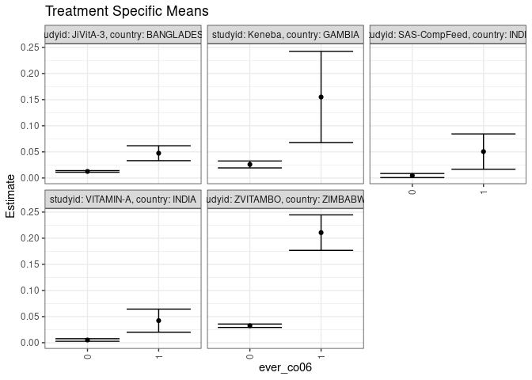

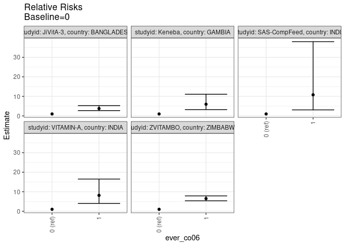

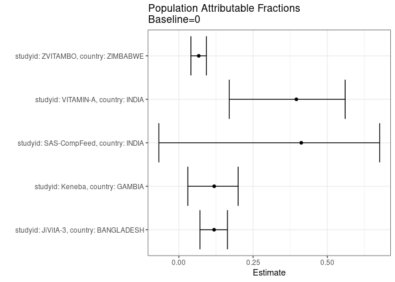

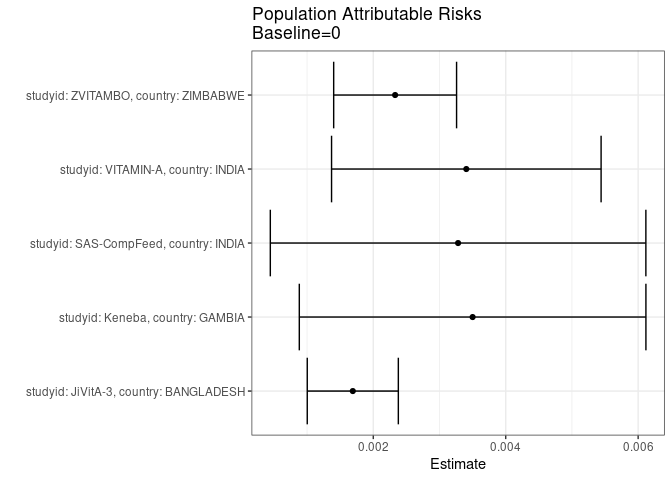

## Results Table

### Parameter: TSM

| studyid | country | intervention_level | baseline_level | estimate | ci_lower | ci_upper |
| --- | --- | --- | --- | --- | --- | --- |
| JiVitA-3 | BANGLADESH | 0 | NA | 0.0125705 | 0.0109856 | 0.0141555 |
| JiVitA-3 | BANGLADESH | 1 | NA | 0.0474452 | 0.0331781 | 0.0617123 |
| Keneba | GAMBIA | 0 | NA | 0.0259244 | 0.0193432 | 0.0325056 |
| Keneba | GAMBIA | 1 | NA | 0.1549879 | 0.0676240 | 0.2423519 |
| SAS-CompFeed | INDIA | 0 | NA | 0.0046729 | 0.0007523 | 0.0085935 |
| SAS-CompFeed | INDIA | 1 | NA | 0.0505051 | 0.0166392 | 0.0843709 |
| VITAMIN-A | INDIA | 0 | NA | 0.0051964 | 0.0027330 | 0.0076598 |
| VITAMIN-A | INDIA | 1 | NA | 0.0422569 | 0.0201593 | 0.0643545 |
| ZVITAMBO | ZIMBABWE | 0 | NA | 0.0324767 | 0.0291909 | 0.0357625 |
| ZVITAMBO | ZIMBABWE | 1 | NA | 0.2107180 | 0.1767526 | 0.2446834 |

### Parameter: E(Y)

| studyid | country | intervention_level | baseline_level | estimate | ci_lower | ci_upper |
| --- | --- | --- | --- | --- | --- | --- |
| JiVitA-3 | BANGLADESH | NA | NA | 0.0142612 | 0.0126245 | 0.0158978 |
| Keneba | GAMBIA | NA | NA | 0.0294245 | 0.0225330 | 0.0363160 |
| SAS-CompFeed | INDIA | NA | NA | 0.0079537 | 0.0042751 | 0.0116324 |
| VITAMIN-A | INDIA | NA | NA | 0.0086016 | 0.0055863 | 0.0116168 |
| ZVITAMBO | ZIMBABWE | NA | NA | 0.0348066 | 0.0314720 | 0.0381412 |

### Parameter: RR

| studyid | country | intervention_level | baseline_level | estimate | ci_lower | ci_upper |
| --- | --- | --- | --- | --- | --- | --- |
| JiVitA-3 | BANGLADESH | 0 | 0 | 1.000000 | 1.000000 | 1.000000 |
| JiVitA-3 | BANGLADESH | 1 | 0 | 3.774311 | 2.713535 | 5.249766 |
| Keneba | GAMBIA | 0 | 0 | 1.000000 | 1.000000 | 1.000000 |
| Keneba | GAMBIA | 1 | 0 | 5.978453 | 3.221677 | 11.094192 |
| SAS-CompFeed | INDIA | 0 | 0 | 1.000000 | 1.000000 | 1.000000 |
| SAS-CompFeed | INDIA | 1 | 0 | 10.808081 | 3.075062 | 37.987725 |
| VITAMIN-A | INDIA | 0 | 0 | 1.000000 | 1.000000 | 1.000000 |
| VITAMIN-A | INDIA | 1 | 0 | 8.131972 | 4.013358 | 16.477218 |
| ZVITAMBO | ZIMBABWE | 0 | 0 | 1.000000 | 1.000000 | 1.000000 |
| ZVITAMBO | ZIMBABWE | 1 | 0 | 6.488281 | 5.364265 | 7.847820 |

### Parameter: PAR

| studyid | country | intervention_level | baseline_level | estimate | ci_lower | ci_upper |
| --- | --- | --- | --- | --- | --- | --- |
| JiVitA-3 | BANGLADESH | 0 | NA | 0.0016906 | 0.0010029 | 0.0023784 |
| Keneba | GAMBIA | 0 | NA | 0.0035001 | 0.0008828 | 0.0061173 |
| SAS-CompFeed | INDIA | 0 | NA | 0.0032808 | 0.0004450 | 0.0061167 |
| VITAMIN-A | INDIA | 0 | NA | 0.0034052 | 0.0013698 | 0.0054405 |
| ZVITAMBO | ZIMBABWE | 0 | NA | 0.0023299 | 0.0014019 | 0.0032579 |

### Parameter: PAF

| studyid | country | intervention_level | baseline_level | estimate | ci_lower | ci_upper |
| --- | --- | --- | --- | --- | --- | --- |
| JiVitA-3 | BANGLADESH | 0 | NA | 0.1185480 | 0.0710751 | 0.1635949 |
| Keneba | GAMBIA | 0 | NA | 0.1189510 | 0.0300558 | 0.1996990 |
| SAS-CompFeed | INDIA | 0 | NA | 0.4124894 | -0.0674433 | 0.6766397 |
| VITAMIN-A | INDIA | 0 | NA | 0.3958776 | 0.1697118 | 0.5604371 |
| ZVITAMBO | ZIMBABWE | 0 | NA | 0.0669377 | 0.0403638 | 0.0927756 |